# Data Characterization & Visualization: Companion Notebook

Author

Erik Westlund

Published

October 5, 2026

This notebook reproduces every data result and figure in the BIDS bootcamp talk *Data Characterization & Visualization*, from start to finish. It uses **Eunomia**, a small synthetic OMOP CDM database that runs entirely on your own computer, so you can run it without access to any real data.

The notebook has two parts:

1. **Characterization.** Connect to Eunomia, build the cohorts, and run the HADES packages (FeatureExtraction and CohortIncidence) plus a few SQL queries.
2. **Visualization.** Turn those results into the figures shown in the talk with ggplot2.

Each figure is shown below and also saved as a PNG in `images/characterization/`, which is where the slides read them from.

# Setup

## Packages

The HADES packages come from the OHDSI GitHub organization. Before running this notebook for the first time, uncomment the install lines and run them once.

```r
# install.packages(c("remotes", "dplyr", "tidyr", "ggplot2", "patchwork", "ragg", "scales"))
# remotes::install_github("OHDSI/Eunomia")
# remotes::install_github("OHDSI/DatabaseConnector")
# remotes::install_github("OHDSI/FeatureExtraction")
# remotes::install_github("OHDSI/CohortIncidence")

library(dplyr)
library(tidyr)
library(ggplot2)
library(patchwork)
```

## Theme and colors

Every figure in the talk uses the Johns Hopkins colors and a theme built on `theme_minimal()`.

```r
theme_set(theme_minimal())

jhu_colors <- list(
  HopkinsBlue = "#002D72",
  Blue = "#005eb8",
  BlueLight = "#68ACE5",
  PaleBlue = "#A7BCD6",
  Purple = "#470a68",
  LightPurple = "#7c7fab",
  Tan = "#D9C89E",
  Gray1 = "#E5E2E0",
  Gray2 = "#B4B2AD",
  Gray3 = "#7E7E7C",
  Gray4 = "#4A484C",
  Gray5 = "#2C2C33",
  Teal = "#6399AE",
  Green = "#007A53"
)

theme_jhu <- function() {
  theme_minimal(base_family = "Tahoma") +
    theme(
      plot.title = element_text(family = "Georgia", size = 18, hjust = 0.5,
                                face = "bold", margin = margin(b = 10)),
      plot.subtitle = element_text(hjust = 0.5, size = 12, margin = margin(t = 5, b = 15)),
      plot.caption = element_text(size = 10, color = jhu_colors$Gray3, margin = margin(t = 15)),
      axis.text = element_text(size = 9, color = jhu_colors$Gray5),
      axis.title.y = element_text(size = 11, face = "bold", margin = margin(r = 15)),
      axis.title.x = element_text(size = 11, face = "bold", margin = margin(t = 15)),
      axis.line = element_line(color = jhu_colors$Gray1, linewidth = 0.5),
      panel.grid.major.x = element_line(color = jhu_colors$Gray1, linewidth = 0.5),
      panel.grid.minor = element_blank()
    )
}

# Save a figure for the slides, at the size the slides expect
image_dir <- "images/characterization"
dir.create(image_dir, recursive = TRUE, showWarnings = FALSE)

save_figure <- function(plot, name, width = 10, height = 5.6) {
  ggsave(file.path(image_dir, paste0(name, ".png")), plot,
         width = width, height = height, dpi = 200, device = ragg::agg_png)
  plot
}
```

# Part 1: Characterization

## Connect to Eunomia and build the cohorts

`Eunomia::createCohorts()` writes four example cohorts to the `cohort` table. We use three of them:

| Cohort ID | Cohort |
| --- | --- |
| 1 | New users of celecoxib |
| 2 | New users of diclofenac |
| 3 | GI bleed |

```r
connection_details <- Eunomia::getEunomiaConnectionDetails()
Eunomia::createCohorts(connection_details)
```

```
Cohorts created in table main.cohort
```

```
  cohortId       name
1        1  Celecoxib
2        2 Diclofenac
3        3    GiBleed
4        4     NSAIDs
                                                                                       description
1    A simplified cohort definition for new users of celecoxib, designed specifically for Eunomia.
2    A simplified cohort definition for new users ofdiclofenac, designed specifically for Eunomia.
3 A simplified cohort definition for gastrointestinal bleeding, designed specifically for Eunomia.
4       A simplified cohort definition for new users of NSAIDs, designed specifically for Eunomia.
  count
1  1844
2   850
3   479
4  2694
```

```r
con <- DatabaseConnector::connect(connection_details)

cohort_names <- c("1" = "Celecoxib", "2" = "Diclofenac", "3" = "GI bleed")
```

## Cohort counts

```r
cohort_counts <- DatabaseConnector::querySql(
  con,
  "SELECT cohort_definition_id, COUNT(DISTINCT subject_id) AS persons
     FROM main.cohort
    WHERE cohort_definition_id IN (1, 2, 3)
    GROUP BY cohort_definition_id",
  snakeCaseToCamelCase = TRUE
) |>
  mutate(cohort = cohort_names[as.character(cohortDefinitionId)])

cohort_counts
```

```
  cohortDefinitionId persons     cohort
1                  1    1844  Celecoxib
2                  2     850 Diclofenac
3                  3     479   GI bleed
```

## Baseline characteristics (FeatureExtraction)

FeatureExtraction computes the covariates behind a “Table 1”: demographics, plus conditions and drugs recorded in the year before cohort entry. With `aggregated = TRUE` it returns summary statistics for the whole cohort.

```r
covariate_settings <- FeatureExtraction::createCovariateSettings(
  useDemographicsGender = TRUE,
  useDemographicsAge = TRUE,
  useDemographicsAgeGroup = TRUE,
  useConditionGroupEraLongTerm = TRUE,
  useDrugGroupEraLongTerm = TRUE,
  longTermStartDays = -365,
  endDays = -1
)

get_covariates <- function(cohort_id) {
  FeatureExtraction::getDbCovariateData(
    connectionDetails = connection_details,
    cdmDatabaseSchema = "main",
    cohortDatabaseSchema = "main",
    cohortTable = "cohort",
    cohortIds = cohort_id,
    covariateSettings = covariate_settings,
    aggregated = TRUE
  )
}
cov_celecoxib <- get_covariates(1)
```

```
Constructing features on server
```

```
Fetching data from server
```

```
Fetching data took 0.23 secs
```

```r
cov_diclofenac <- get_covariates(2)
```

```
Constructing features on server
```

```
Fetching data from server
```

```
Fetching data took 0.131 secs
```

```r
smd_all <- FeatureExtraction::computeStandardizedDifference(cov_celecoxib, cov_diclofenac) |>
  as_tibble()
```

The standardized mean difference (SMD) is the difference between the cohorts on a covariate, in standard deviation units. We keep 20 covariates for the Table 1. FeatureExtraction computes (comparator − target), so we flip the sign: a positive SMD means the covariate is more common among celecoxib users.

```r
picked <- tribble(
  ~covariateId, ~covariate,
  8532001,      "Female",
  6003,         "Age 30-34",
  7003,         "Age 35-39",
  8003,         "Age 40-44",
  9003,         "Age 45-49",
  4285898210,   "Polyp of colon",
  30753210,     "Esophagitis",
  81893210,     "Ulcerative colitis",
  4310024210,   "Angiodysplasia of stomach",
  4112343210,   "Acute viral pharyngitis",
  4283893210,   "Sinusitis",
  260139210,    "Acute bronchitis",
  372328210,    "Otitis media",
  81151210,     "Sprain of ankle",
  1125315410,   "Acetaminophen",
  1713332410,   "Amoxicillin",
  1177480410,   "Ibuprofen",
  1115008410,   "Naproxen",
  1112807410,   "Aspirin",
  1322184410,   "Clopidogrel"
)

table1 <- picked |>
  left_join(smd_all, by = "covariateId") |>
  transmute(
    covariate,
    pct_celecoxib = round(100 * mean1, 1),
    pct_diclofenac = round(100 * mean2, 1),
    smd = round(-stdDiff, 3)
  )

table1
```

```
# A tibble: 20 × 4
   covariate                 pct_celecoxib pct_diclofenac    smd
   <chr>                             <dbl>          <dbl>  <dbl>
 1 Female                             50.4           52.1 -0.034
 2 Age 30-34                          11.3           11.8 -0.013
 3 Age 35-39                          48             49.4 -0.028
 4 Age 40-44                          36.7           35.8  0.019
 5 Age 45-49                           4              3.1  0.052
 6 Polyp of colon                     17.1            7.5  0.295
 7 Esophagitis                        10              4.4  0.219
 8 Ulcerative colitis                  3.1            1.1  0.143
 9 Angiodysplasia of stomach           0.5            0    0.099
10 Acute viral pharyngitis             7.5            4.8  0.113
11 Sinusitis                          12.1           13.5 -0.043
12 Acute bronchitis                    4.8            4.8  0
13 Otitis media                        0.7            0.1  0.086
14 Sprain of ankle                     0.7            1.5 -0.078
15 Acetaminophen                       7.4            7.2  0.01
16 Amoxicillin                         2.4            2.9 -0.034
17 Ibuprofen                           1.1            1.8 -0.052
18 Naproxen                            1              0.9  0.009
19 Aspirin                             0.3            0.5 -0.033
20 Clopidogrel                         0.5            0.7 -0.021
```

## Age and sex

FeatureExtraction gives age and sex separately. For the age-by-sex figures we need the joint distribution, so we query the `cohort` and `person` tables directly.

```r
age_sex_counts <- DatabaseConnector::renderTranslateQuerySql(
  con,
  "SELECT c.cohort_definition_id,
          FLOOR((YEAR(c.cohort_start_date) - p.year_of_birth) / 5) * 5 AS age_group,
          p.gender_concept_id,
          COUNT(*) AS persons
     FROM main.cohort c
     JOIN main.person p ON p.person_id = c.subject_id
    WHERE c.cohort_definition_id IN (1, 2)
    GROUP BY c.cohort_definition_id,
             FLOOR((YEAR(c.cohort_start_date) - p.year_of_birth) / 5) * 5,
             p.gender_concept_id",
  snakeCaseToCamelCase = TRUE
) |>
  mutate(
    cohort = cohort_names[as.character(cohortDefinitionId)],
    sex = if_else(genderConceptId == 8507, "Male", "Female")
  )

# Percent of each cohort in each age group and sex
age_sex <- age_sex_counts |>
  group_by(cohort) |>
  mutate(
    pct = 100 * persons / sum(persons),
    age = paste0(ageGroup, "-", ageGroup + 4),
    pct_signed = if_else(sex == "Female", -pct, pct)  # women's bars point left in the pyramid
  ) |>
  ungroup()

age_sex
```

```
# A tibble: 16 × 9
   cohortDefinitionId ageGroup genderConceptId persons cohort  sex     pct age
                <dbl>    <dbl>           <dbl>   <dbl> <chr>   <chr> <dbl> <chr>
 1                  1       30            8507      96 Celeco… Male   5.21 30-34
 2                  1       30            8532     113 Celeco… Fema…  6.13 30-34
 3                  1       35            8507     455 Celeco… Male  24.7  35-39
 4                  1       35            8532     430 Celeco… Fema… 23.3  35-39
 5                  1       40            8507     333 Celeco… Male  18.1  40-44
 6                  1       40            8532     343 Celeco… Fema… 18.6  40-44
 7                  1       45            8507      30 Celeco… Male   1.63 45-49
 8                  1       45            8532      44 Celeco… Fema…  2.39 45-49
 9                  2       30            8507      45 Diclof… Male   5.29 30-34
10                  2       30            8532      55 Diclof… Fema…  6.47 30-34
11                  2       35            8507     214 Diclof… Male  25.2  35-39
12                  2       35            8532     206 Diclof… Fema… 24.2  35-39
13                  2       40            8507     138 Diclof… Male  16.2  40-44
14                  2       40            8532     166 Diclof… Fema… 19.5  40-44
15                  2       45            8507      10 Diclof… Male   1.18 45-49
16                  2       45            8532      16 Diclof… Fema…  1.88 45-49
# ℹ 1 more variable: pct_signed <dbl>
```

## Incidence (CohortIncidence)

CohortIncidence computes incidence rates. The design below counts first GI bleeds in the 365 days after drug start, stratified by age group, sex, and calendar year.

```r
ir_design <- CohortIncidence::createIncidenceDesign(
  targetDefs = list(
    CohortIncidence::createCohortRef(id = 1, name = "Celecoxib"),
    CohortIncidence::createCohortRef(id = 2, name = "Diclofenac")
  ),
  outcomeDefs = list(
    CohortIncidence::createOutcomeDef(id = 1, name = "GI bleed", cohortId = 3, cleanWindow = 9999)
  ),
  tars = list(
    CohortIncidence::createTimeAtRiskDef(id = 1, startWith = "start", endWith = "start", endOffset = 365)
  ),
  analysisList = list(
    CohortIncidence::createIncidenceAnalysis(targets = c(1, 2), outcomes = 1, tars = 1)
  ),
  strataSettings = CohortIncidence::createStrataSettings(
    byAge = TRUE, ageBreaks = c(35, 40, 45), byGender = TRUE, byYear = TRUE
  )
)

ir_results <- CohortIncidence::executeAnalysis(
  connectionDetails = connection_details,
  incidenceDesign = ir_design,
  buildOptions = CohortIncidence::buildOptions(
    cohortTable = "main.cohort",
    cdmDatabaseSchema = "main",
    sourceName = "Eunomia GiBleed",
    refId = 1
  )
)
```

The results include every combination of strata. For the figures we keep the rows stratified by age group and sex (not by year), and give the age groups readable labels in age order.

```r
age_labels <- c("<35" = "30-34", "35 - 39" = "35-39", "40 - 44" = "40-44", ">=45" = "45-49")

ir <- ir_results$incidence_summary |>
  rename_with(tolower) |>
  left_join(ir_results$age_group_def |> rename_with(tolower) |> select(age_group_id, age_group_name),
            by = "age_group_id") |>
  mutate(
    cohort = cohort_names[as.character(target_cohort_definition_id)],
    sex = case_when(gender_id == 8507 ~ "Male", gender_id == 8532 ~ "Female"),
    person_years = person_days / 365.25,
    ir_per_1000py = 1000 * outcomes / person_years
  ) |>
  filter(is.na(start_year), !is.na(age_group_name), !is.na(sex)) |>
  mutate(age_group = factor(age_labels[age_group_name], levels = age_labels))

ir |> select(cohort, sex, age_group, outcomes, person_years, ir_per_1000py)
```

```
       cohort    sex age_group outcomes person_years ir_per_1000py
1   Celecoxib   Male     30-34       18    79.195072      227.2869
2   Celecoxib Female     30-34       17    94.913073      179.1113
3   Celecoxib   Male     35-39       85   365.327858      232.6677
4   Celecoxib Female     35-39       92   337.705681      272.4266
5   Celecoxib   Male     40-44       71   263.063655      269.8967
6   Celecoxib Female     40-44       58   280.309377      206.9142
7   Celecoxib   Male     45-49        6    25.040383      239.6129
8   Celecoxib Female     45-49        8    35.044490      228.2812
9  Diclofenac   Male     30-34        5    40.999316      121.9533
10 Diclofenac Female     30-34        9    45.700205      196.9357
11 Diclofenac   Male     35-39       30   179.696099      166.9485
12 Diclofenac Female     35-39       27   176.032854      153.3805
13 Diclofenac   Male     40-44       19   114.283368      166.2534
14 Diclofenac Female     40-44       27   138.308008      195.2165
15 Diclofenac   Male     45-49        3     7.216975      415.6866
16 Diclofenac Female     45-49        4    12.355921      323.7314
```

## Time to event

Days from drug start to the first GI bleed after it, for people who bled.

```r
tte <- DatabaseConnector::renderTranslateQuerySql(
  con,
  "SELECT t.cohort_definition_id, t.subject_id,
          MIN(DATEDIFF(DAY, t.cohort_start_date, o.cohort_start_date)) AS days_to_event
     FROM main.cohort t
     JOIN main.cohort o
       ON o.subject_id = t.subject_id
      AND o.cohort_definition_id = 3
      AND o.cohort_start_date >= t.cohort_start_date
    WHERE t.cohort_definition_id IN (1, 2)
    GROUP BY t.cohort_definition_id, t.subject_id",
  snakeCaseToCamelCase = TRUE
) |>
  mutate(cohort = cohort_names[as.character(cohortDefinitionId)])

DatabaseConnector::disconnect(con)

tte |> count(cohort)
```

```
      cohort   n
1  Celecoxib 355
2 Diclofenac 124
```

# Part 2: Visualization

## Building a figure in four steps

Each step adds one layer to the same plot.

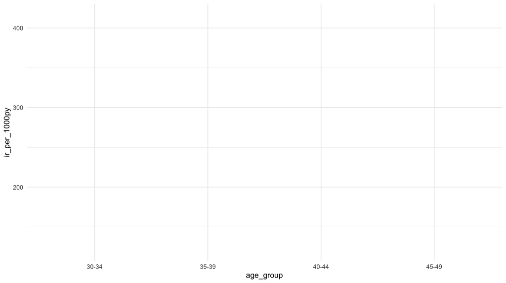

```r
save_step <- function(plot, step) {
  save_figure(plot, paste0("ggplot-build-", step), width = 8, height = 5)
}

# 1. Data and aesthetic mapping: axes, but nothing drawn yet
p1 <- ggplot(ir, aes(x = age_group, y = ir_per_1000py))
save_step(p1, 1)
```

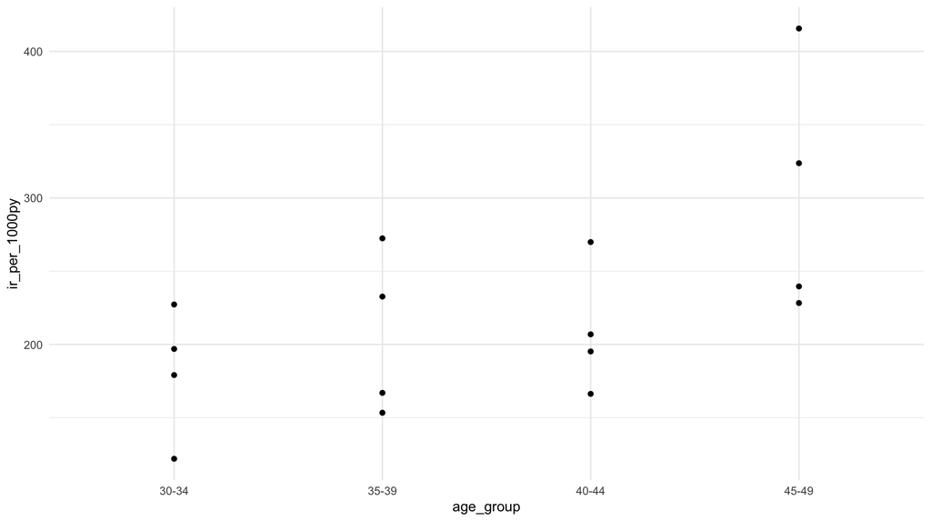

```r
# 2. Add a geometry: one point per row
p2 <- p1 + geom_point()
save_step(p2, 2)
```

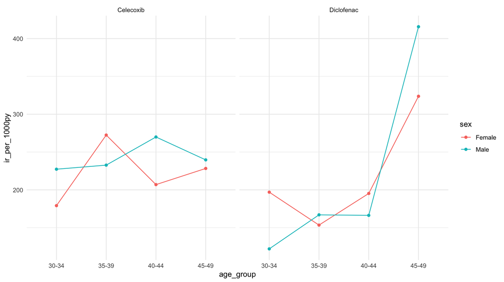

```r
# 3. Color by sex, connect with lines, and one panel per drug
p3 <- p2 +
  aes(color = sex, group = sex) +
  geom_line() +
  facet_wrap(~cohort)
save_step(p3, 3)
```

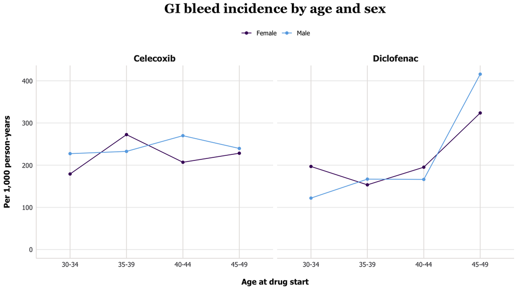

```r
# 4. Colors, labels, and a theme
p4 <- p3 +
  scale_color_manual(values = c(Female = jhu_colors$Purple, Male = jhu_colors$BlueLight)) +
  labs(
    title = "GI bleed incidence by age and sex",
    x = "Age at drug start", y = "Per 1,000 person-years", color = NULL
  ) +
  expand_limits(y = 0) +
  theme_jhu() +
  theme(legend.position = "top", strip.text = element_text(size = 12, face = "bold"))
save_step(p4, 4)
```

## Visualization principles

These figures use small made-up numbers, not Eunomia, so each principle is easy to see.

### Principle 1: Use a common scale

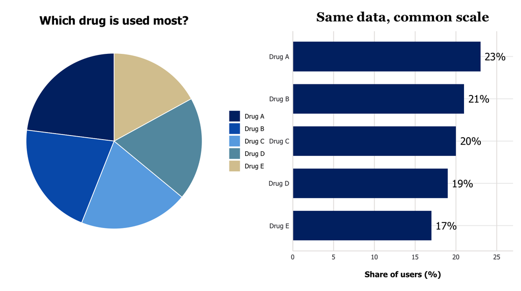

```r
shares <- tibble(
  drug = c("Drug A", "Drug B", "Drug C", "Drug D", "Drug E"),
  pct = c(23, 21, 20, 19, 17)
)

pie <- ggplot(shares, aes(x = "", y = pct, fill = drug)) +
  geom_col(width = 1, color = "white") +
  coord_polar(theta = "y") +
  scale_fill_manual(values = unname(unlist(jhu_colors[c(
    "HopkinsBlue", "Blue", "BlueLight", "Teal", "Tan"
  )]))) +
  labs(title = "Which drug is used most?", fill = NULL) +
  theme_void(base_family = "Tahoma") +
  theme(plot.title = element_text(hjust = 0.5, face = "bold", size = 16))

bars <- ggplot(shares, aes(x = pct, y = reorder(drug, pct))) +
  geom_col(fill = jhu_colors$HopkinsBlue, width = 0.7) +
  geom_text(aes(label = paste0(pct, "%")), hjust = -0.2, size = 5) +
  scale_x_continuous(limits = c(0, 27), expand = c(0, 0)) +
  labs(title = "Same data, common scale", x = "Share of users (%)", y = NULL) +
  theme_jhu()

save_figure(pie + bars, "principle-pie-vs-bars")
```

### Principle 2: Start bars at zero

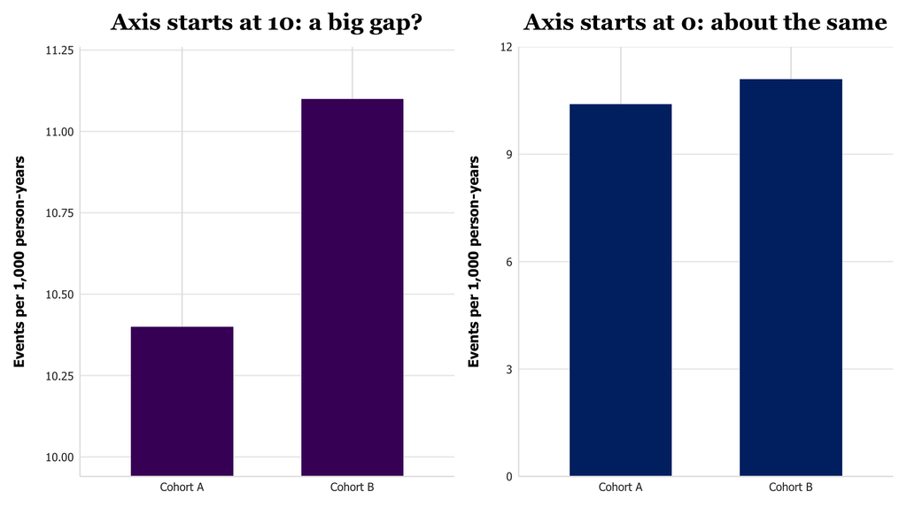

```r
rates <- tibble(group = c("Cohort A", "Cohort B"), rate = c(10.4, 11.1))

truncated <- ggplot(rates, aes(x = group, y = rate)) +
  geom_col(fill = jhu_colors$Purple, width = 0.6) +
  coord_cartesian(ylim = c(10, 11.2)) +
  labs(title = "Axis starts at 10: a big gap?", x = NULL,
       y = "Events per 1,000 person-years") +
  theme_jhu()

full <- ggplot(rates, aes(x = group, y = rate)) +
  geom_col(fill = jhu_colors$HopkinsBlue, width = 0.6) +
  scale_y_continuous(limits = c(0, 12), expand = c(0, 0)) +
  labs(title = "Axis starts at 0: about the same", x = NULL,
       y = "Events per 1,000 person-years") +
  theme_jhu()

save_figure(truncated + full, "principle-honest-axis")
```

### Principle 3: Order categories meaningfully

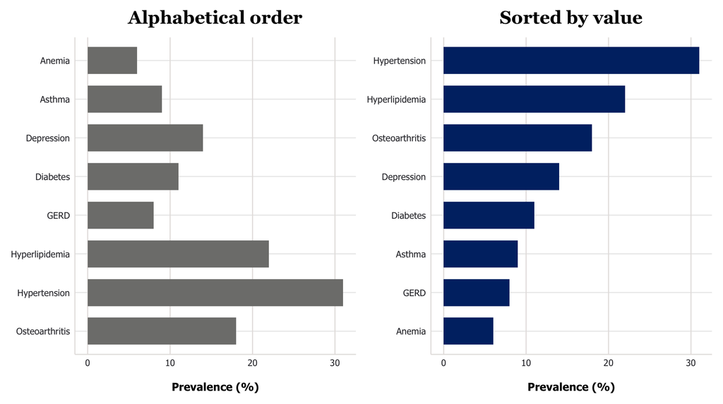

```r
conditions <- tibble(
  condition = c("Anemia", "Asthma", "Depression", "Diabetes", "GERD",
                "Hyperlipidemia", "Hypertension", "Osteoarthritis"),
  pct = c(6, 9, 14, 11, 8, 22, 31, 18)
)

alphabetical <- ggplot(conditions, aes(x = pct, y = factor(condition, levels = rev(sort(condition))))) +
  geom_col(fill = jhu_colors$Gray3, width = 0.7) +
  labs(title = "Alphabetical order", x = "Prevalence (%)", y = NULL) +
  theme_jhu()

sorted <- ggplot(conditions, aes(x = pct, y = reorder(condition, pct))) +
  geom_col(fill = jhu_colors$HopkinsBlue, width = 0.7) +
  labs(title = "Sorted by value", x = "Prevalence (%)", y = NULL) +
  theme_jhu()

save_figure(alphabetical + sorted, "principle-order")
```

### Principle 4: Label directly

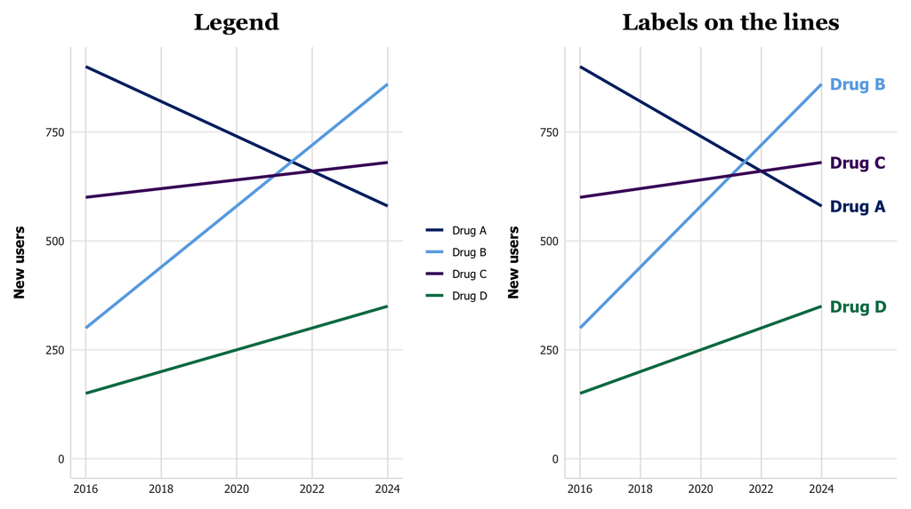

```r
drug_colors_4 <- c(
  "Drug A" = jhu_colors$HopkinsBlue, "Drug B" = jhu_colors$BlueLight,
  "Drug C" = jhu_colors$Purple, "Drug D" = jhu_colors$Green
)

uptake <- expand_grid(drug = names(drug_colors_4), year = 2016:2024) |>
  mutate(users = case_when(
    drug == "Drug A" ~ 900 - 40 * (year - 2016),
    drug == "Drug B" ~ 300 + 70 * (year - 2016),
    drug == "Drug C" ~ 600 + 10 * (year - 2016),
    drug == "Drug D" ~ 150 + 25 * (year - 2016)
  ))

with_legend <- ggplot(uptake, aes(x = year, y = users, color = drug)) +
  geom_line(linewidth = 1.1) +
  scale_color_manual(values = drug_colors_4) +
  expand_limits(y = 0) +
  labs(title = "Legend", x = NULL, y = "New users", color = NULL) +
  theme_jhu() +
  theme(legend.position = "right")

with_labels <- ggplot(uptake, aes(x = year, y = users, color = drug)) +
  geom_line(linewidth = 1.1) +
  geom_text(data = filter(uptake, year == max(year)),
            aes(label = drug), hjust = -0.15, size = 4.5, fontface = "bold") +
  scale_color_manual(values = drug_colors_4, guide = "none") +
  scale_x_continuous(limits = c(2016, 2026), breaks = seq(2016, 2024, 2)) +
  expand_limits(y = 0) +
  labs(title = "Labels on the lines", x = NULL, y = "New users") +
  theme_jhu()

save_figure(with_legend + with_labels, "principle-direct-labels")
```

### Principle 5: Use small multiples

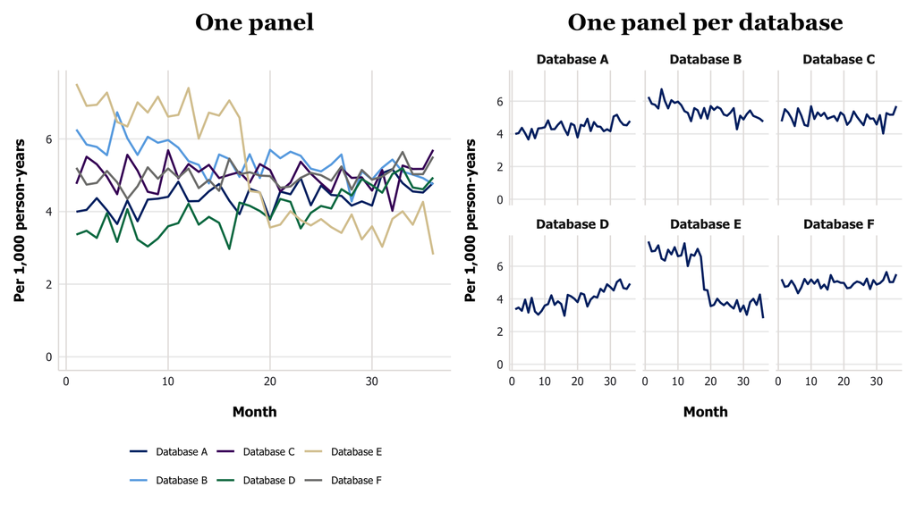

```r
set.seed(20261005)
databases <- paste("Database", LETTERS[1:6])
monthly <- expand_grid(database = databases, month = 1:36) |>
  mutate(
    base = c(4, 6, 5, 3, 7, 5)[match(database, databases)],
    trend = c(0.02, -0.03, 0, 0.05, -0.01, 0)[match(database, databases)],
    jump = if_else(database == "Database E" & month >= 18, -3, 0),  # a coding change
    rate = base + trend * month + jump + rnorm(n(), 0, 0.35)
  )

db_colors <- setNames(
  unname(unlist(jhu_colors[c("HopkinsBlue", "BlueLight", "Purple", "Green", "Tan", "Gray3")])),
  databases
)

tangled <- ggplot(monthly, aes(x = month, y = rate, color = database)) +
  geom_line(linewidth = 0.8) +
  scale_color_manual(values = db_colors) +
  expand_limits(y = 0) +
  labs(title = "One panel", x = "Month", y = "Per 1,000 person-years", color = NULL) +
  theme_jhu() +
  theme(legend.position = "bottom", legend.text = element_text(size = 8))

multiples <- ggplot(monthly, aes(x = month, y = rate)) +
  geom_line(color = jhu_colors$HopkinsBlue, linewidth = 0.8) +
  facet_wrap(~database, ncol = 3) +
  expand_limits(y = 0) +
  labs(title = "One panel per database", x = "Month", y = "Per 1,000 person-years") +
  theme_jhu() +
  theme(strip.text = element_text(size = 10, face = "bold"))

save_figure(tangled + multiples, "principle-small-multiples")
```

### Principle 6: Use color to highlight

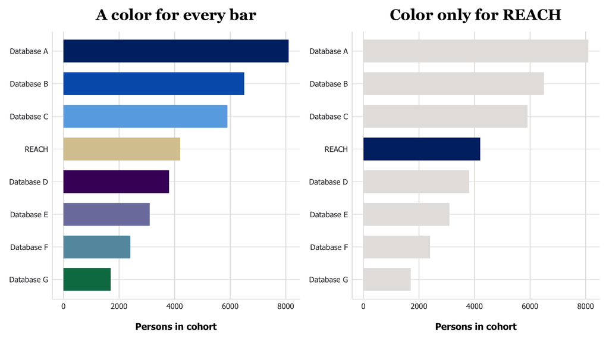

```r
sites <- tibble(
  database = c("REACH", paste("Database", LETTERS[1:7])),
  persons = c(4200, 8100, 6500, 5900, 3800, 3100, 2400, 1700)
)

rainbow <- ggplot(sites, aes(x = persons, y = reorder(database, persons), fill = database)) +
  geom_col(width = 0.7) +
  scale_fill_manual(values = unname(unlist(jhu_colors[c(
    "HopkinsBlue", "Blue", "BlueLight", "Purple", "LightPurple", "Teal", "Green", "Tan"
  )])), guide = "none") +
  labs(title = "A color for every bar", x = "Persons in cohort", y = NULL) +
  theme_jhu()

highlight <- ggplot(sites, aes(x = persons, y = reorder(database, persons),
                               fill = database == "REACH")) +
  geom_col(width = 0.7) +
  scale_fill_manual(values = c(`TRUE` = jhu_colors$HopkinsBlue, `FALSE` = jhu_colors$Gray1),
                    guide = "none") +
  labs(title = "Color only for REACH", x = "Persons in cohort", y = NULL) +
  theme_jhu()

save_figure(rainbow + highlight, "principle-highlight")
```

### Principle 7: State the finding in the title

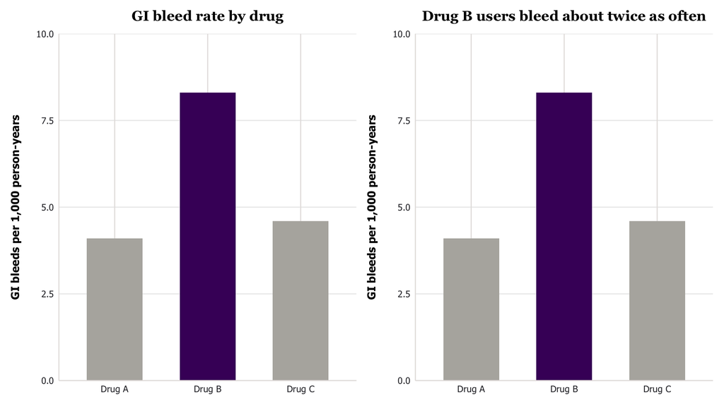

```r
bleeds <- tibble(drug = c("Drug A", "Drug B", "Drug C"), rate = c(4.1, 8.3, 4.6))

bleed_bars <- function(title) {
  ggplot(bleeds, aes(x = drug, y = rate)) +
    geom_col(fill = if_else(bleeds$drug == "Drug B", jhu_colors$Purple, jhu_colors$Gray2),
             width = 0.6) +
    scale_y_continuous(limits = c(0, 10), expand = c(0, 0)) +
    labs(title = title, x = NULL, y = "GI bleeds per 1,000 person-years") +
    theme_jhu() +
    theme(plot.title = element_text(size = 14))
}

save_figure(bleed_bars("GI bleed rate by drug") + bleed_bars("Drug B users bleed about twice as often"),
            "principle-title")
```

## Example: cohort sizes

A workhorse first draft with default settings, then a show pony: sorted, horizontal, labeled, and themed.

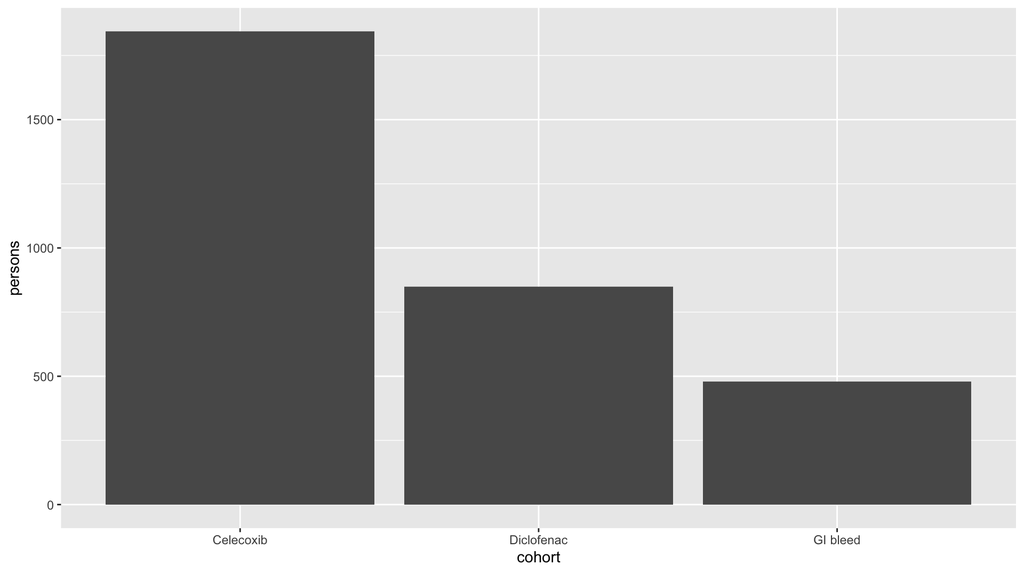

```r
p_counts_plain <- ggplot(cohort_counts, aes(x = cohort, y = persons)) +
  geom_col() +
  theme_gray()
save_figure(p_counts_plain, "counts-plain")
```

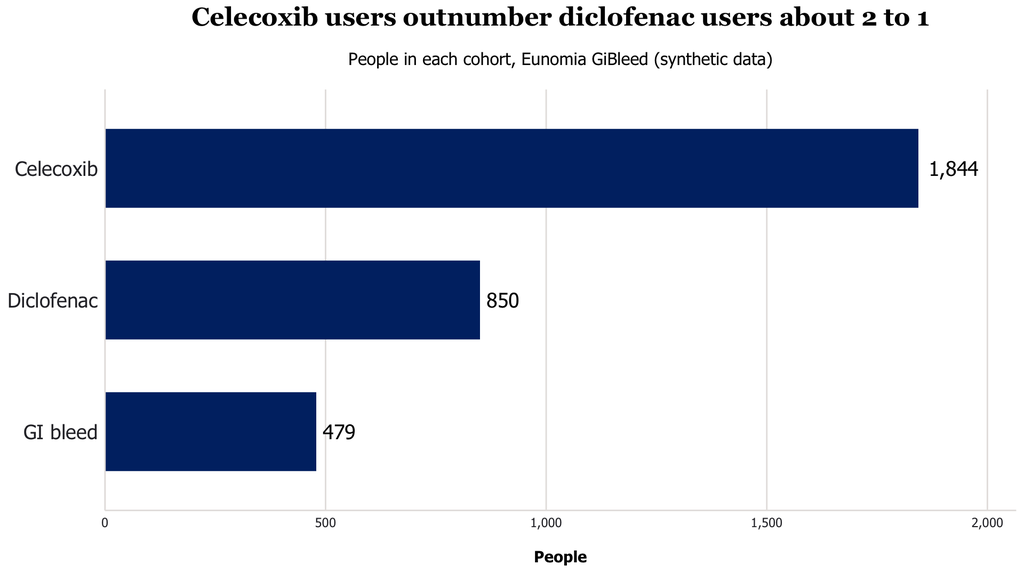

```r
p_counts_polished <- ggplot(cohort_counts, aes(x = persons, y = reorder(cohort, persons))) +
  geom_col(fill = jhu_colors$HopkinsBlue, width = 0.6) +
  geom_text(aes(label = scales::comma(persons)), hjust = -0.2, size = 5) +
  scale_x_continuous(expand = expansion(mult = c(0, 0.12)), labels = scales::comma) +
  labs(
    title = "Celecoxib users outnumber diclofenac users about 2 to 1",
    subtitle = "People in each cohort, Eunomia GiBleed (synthetic data)",
    x = "People", y = NULL
  ) +
  theme_jhu() +
  theme(axis.text.y = element_text(size = 14), panel.grid.major.y = element_blank())
save_figure(p_counts_polished, "counts-polished")
```

## Example: incidence by age and sex

Three versions: default settings, a workhorse, and a show pony built on the workhorse.

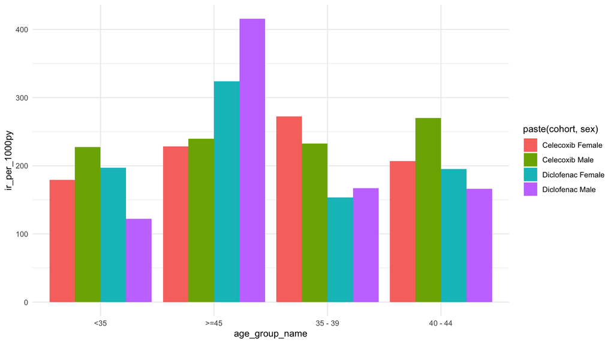

```r
# Defaults only: text age groups sort alphabetically, and four colors to decode
p_ir_plain <- ggplot(ir, aes(x = age_group_name, y = ir_per_1000py, fill = paste(cohort, sex))) +
  geom_col(position = "dodge")
save_figure(p_ir_plain, "incidence-plain")
```

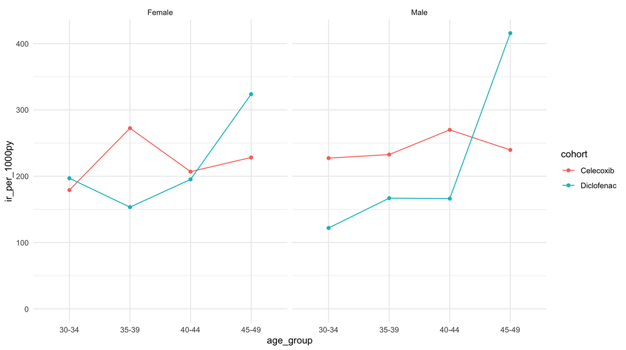

```r
# Workhorse: ages in order, one panel per sex, y axis from zero
p_ir_workhorse <- ggplot(ir, aes(x = age_group, y = ir_per_1000py, color = cohort)) +
  geom_line(aes(group = cohort)) +
  geom_point() +
  facet_wrap(~sex) +
  expand_limits(y = 0)
save_figure(p_ir_workhorse, "incidence-workhorse")
```

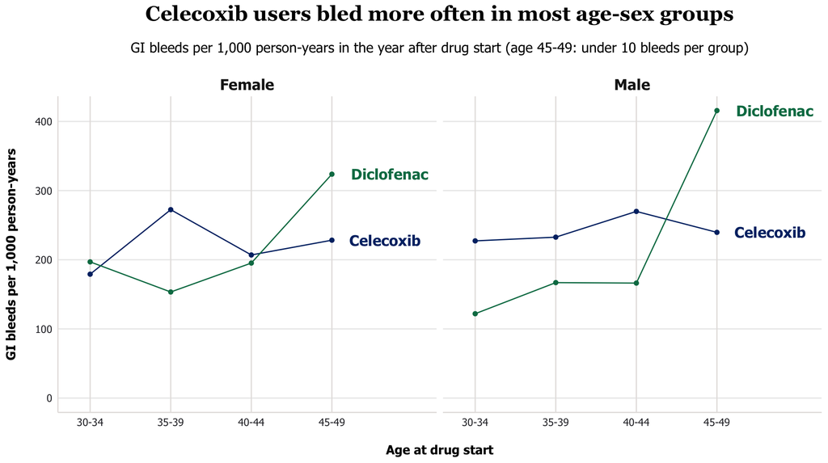

```r
# Show pony: the workhorse plus direct labels, colors, titles, and a theme
drug_colors <- c(Celecoxib = jhu_colors$HopkinsBlue, Diclofenac = jhu_colors$Green)

p_ir_polished <- p_ir_workhorse +
  # Label each line at its last point (age 45-49)
  geom_text(data = \(d) filter(d, age_group == "45-49"), aes(label = cohort),
            hjust = -0.25, fontface = "bold", size = 4.5) +
  scale_color_manual(values = drug_colors, guide = "none") +
  # Extra room on the right for the labels
  scale_x_discrete(expand = expansion(add = c(0.4, 1.3))) +
  labs(
    title = "Celecoxib users bled more often in most age-sex groups",
    subtitle = "GI bleeds per 1,000 person-years in the year after drug start (age 45-49: under 10 bleeds per group)",
    x = "Age at drug start", y = "GI bleeds per 1,000 person-years"
  ) +
  theme_jhu() +
  theme(strip.text = element_text(size = 13, face = "bold"))
save_figure(p_ir_polished, "incidence-polished")
```

## Example: Table 1 as a figure

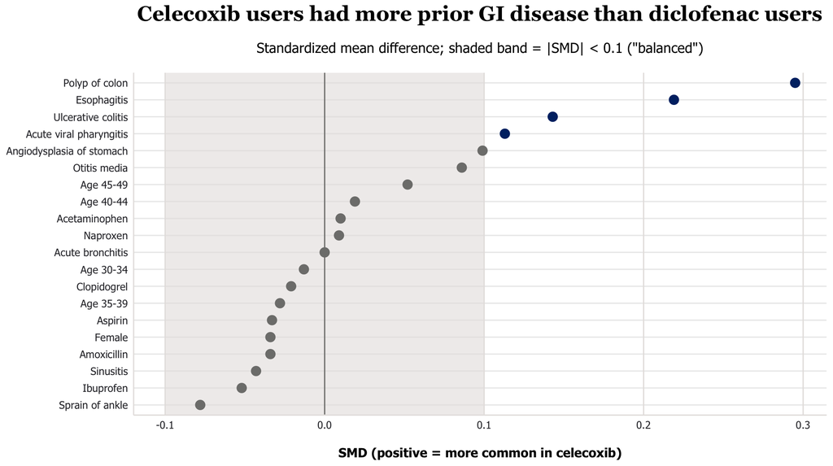

```r
p_smd <- ggplot(table1, aes(x = smd, y = reorder(covariate, smd))) +
  annotate("rect", xmin = -0.1, xmax = 0.1, ymin = -Inf, ymax = Inf,
           fill = jhu_colors$Gray1, alpha = 0.6) +
  geom_vline(xintercept = 0, color = jhu_colors$Gray3) +
  geom_point(aes(color = abs(smd) > 0.1), size = 3.5) +
  scale_color_manual(values = c(`FALSE` = jhu_colors$Gray3, `TRUE` = jhu_colors$HopkinsBlue),
                     guide = "none") +
  labs(
    title = "Celecoxib users had more prior GI disease than diclofenac users",
    subtitle = "Standardized mean difference; shaded band = |SMD| < 0.1 (\"balanced\")",
    x = "SMD (positive = more common in celecoxib)", y = NULL
  ) +
  theme_jhu()
save_figure(p_smd, "table1-smd-plot")
```

## Example: four views of age and sex

The same `age_sex` table, plotted four ways. Only the geoms and facets change.

```r
sex_colors <- c(Female = jhu_colors$Purple, Male = jhu_colors$BlueLight)
age_sex_title <- "Age and sex distribution by cohort"
age_sex_subtitle <- "Percent of each cohort by age group and sex at drug start"

theme_age_sex <- function() {
  theme_jhu() +
    theme(legend.position = "top", strip.text = element_text(size = 13, face = "bold"))
}
```

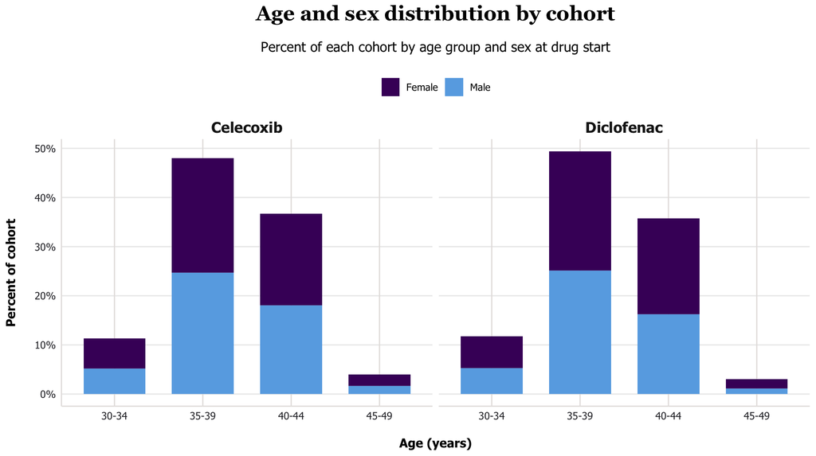

```r
# 1. Stacked bars
p_stacked <- ggplot(age_sex, aes(x = age, y = pct, fill = sex)) +
  geom_col(width = 0.7) +
  facet_wrap(~cohort) +
  scale_fill_manual(values = sex_colors) +
  scale_y_continuous(labels = \(x) paste0(x, "%")) +
  labs(title = age_sex_title, subtitle = age_sex_subtitle,
       x = "Age (years)", y = "Percent of cohort", fill = NULL) +
  theme_age_sex()
save_figure(p_stacked, "age-sex-stacked")
```

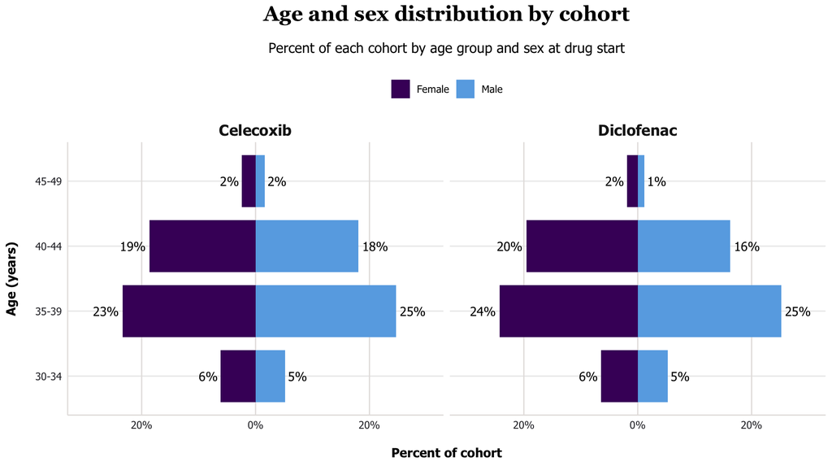

```r
# 2. Pyramid: women's values are negative, so their bars point left
p_pyramid <- ggplot(age_sex, aes(x = pct_signed, y = age, fill = sex)) +
  geom_col(width = 0.8) +
  geom_text(aes(label = sprintf("%.0f%%", pct),
                hjust = if_else(sex == "Female", 1.15, -0.15)), size = 3.8) +
  facet_wrap(~cohort) +
  scale_x_continuous(labels = \(x) paste0(abs(x), "%"), limits = c(-30, 30)) +
  scale_fill_manual(values = sex_colors) +
  labs(title = age_sex_title, subtitle = age_sex_subtitle,
       x = "Percent of cohort", y = "Age (years)", fill = NULL) +
  theme_age_sex()
save_figure(p_pyramid, "age-sex-pyramid")
```

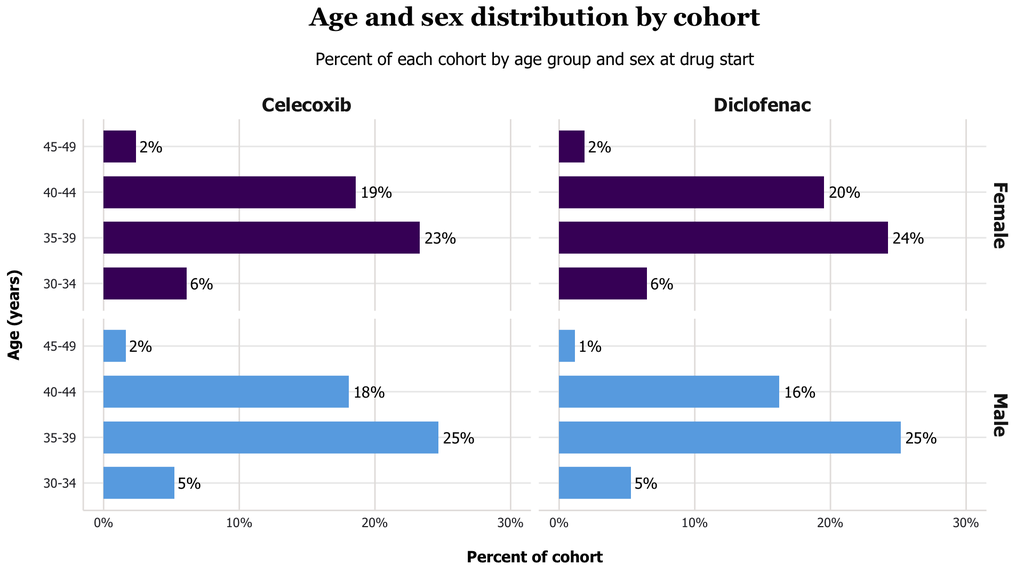

```r
# 3. Facets: one panel per cohort and sex
p_faceted <- ggplot(age_sex, aes(x = pct, y = age, fill = sex)) +
  geom_col(width = 0.7) +
  geom_text(aes(label = sprintf("%.0f%%", pct)), hjust = -0.15, size = 3.8) +
  facet_grid(sex ~ cohort) +
  scale_x_continuous(labels = \(x) paste0(x, "%"), limits = c(0, 30)) +
  scale_fill_manual(values = sex_colors, guide = "none") +
  labs(title = age_sex_title, subtitle = age_sex_subtitle,
       x = "Percent of cohort", y = "Age (years)") +
  theme_age_sex()
save_figure(p_faceted, "age-sex-faceted")
```

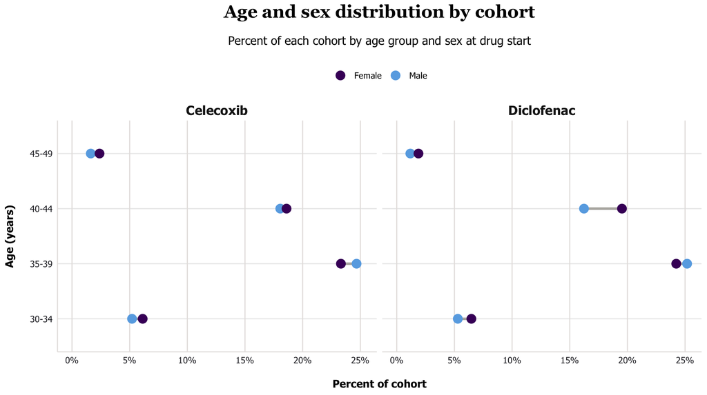

```r
# 4. Connected dot plot: women and men on one scale in each row
p_dotplot <- ggplot(age_sex, aes(x = pct, y = age)) +
  geom_line(aes(group = age), color = jhu_colors$Gray2, linewidth = 1.2) +
  geom_point(aes(color = sex), size = 4) +
  facet_wrap(~cohort) +
  scale_x_continuous(labels = \(x) paste0(x, "%"), limits = c(0, NA)) +
  scale_color_manual(values = sex_colors) +
  labs(title = age_sex_title, subtitle = age_sex_subtitle,
       x = "Percent of cohort", y = "Age (years)", color = NULL) +
  theme_age_sex()
save_figure(p_dotplot, "age-sex-dotplot")
```

## Example: four views of time to GI bleed

```r
# Bleeds per week, by the day each week starts
tte_weekly <- tte |>
  mutate(week_start = 7 * floor(daysToEvent / 7)) |>
  count(cohort, week_start)

# Cumulative percent of each cohort's bleeds by day
tte_cum <- tte |>
  arrange(cohort, daysToEvent) |>
  group_by(cohort) |>
  mutate(pct = 100 * row_number() / n()) |>
  ungroup()

n_users <- setNames(cohort_counts$persons, cohort_counts$cohort)
n_bleeds <- table(tte$cohort)
tte_title <- "Days from drug start to first GI bleed"
tte_subtitle <- sprintf(
  "People with a GI bleed: %d of %s celecoxib users and %d of %s diclofenac users",
  n_bleeds[["Celecoxib"]], scales::comma(n_users[["Celecoxib"]]),
  n_bleeds[["Diclofenac"]], scales::comma(n_users[["Diclofenac"]])
)
day_axis <- scale_x_continuous(breaks = seq(0, 91, by = 14), limits = c(0, 91))
```

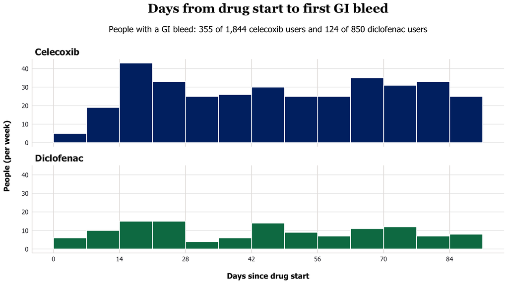

```r
# 1. Histogram: counts per week, one panel per drug, common y axis
p_hist <- ggplot(tte, aes(x = daysToEvent, fill = cohort)) +
  geom_histogram(binwidth = 7, boundary = 0, closed = "left", color = "white") +
  facet_wrap(~cohort, ncol = 1) +
  scale_fill_manual(values = drug_colors, guide = "none") +
  day_axis +
  labs(title = tte_title, subtitle = tte_subtitle,
       x = "Days since drug start", y = "People (per week)") +
  theme_jhu() +
  theme(strip.text = element_text(size = 13, face = "bold", hjust = 0))
save_figure(p_hist, "time-to-event-histogram")
```

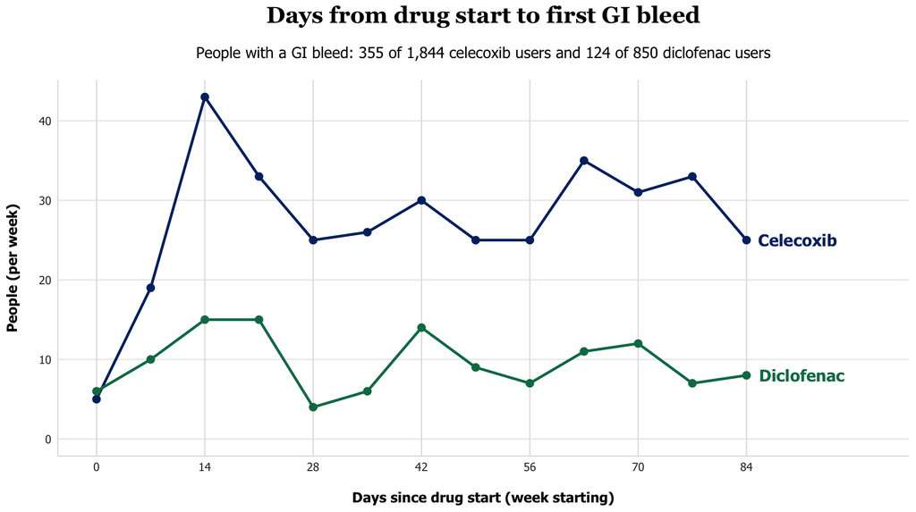

```r
# 2. Weekly counts as connected lines on one panel
p_lines <- ggplot(tte_weekly, aes(x = week_start, y = n, color = cohort)) +
  geom_line(linewidth = 1) +
  geom_point(size = 2.5) +
  geom_text(data = \(d) slice_max(d, week_start, by = cohort),
            aes(label = cohort), hjust = -0.15, fontface = "bold", size = 4.5) +
  scale_color_manual(values = drug_colors, guide = "none") +
  scale_x_continuous(breaks = seq(0, 91, by = 14), limits = c(0, 100)) +
  expand_limits(y = 0) +
  labs(title = tte_title, subtitle = tte_subtitle,
       x = "Days since drug start (week starting)", y = "People (per week)") +
  theme_jhu()
save_figure(p_lines, "time-to-event-lines")
```

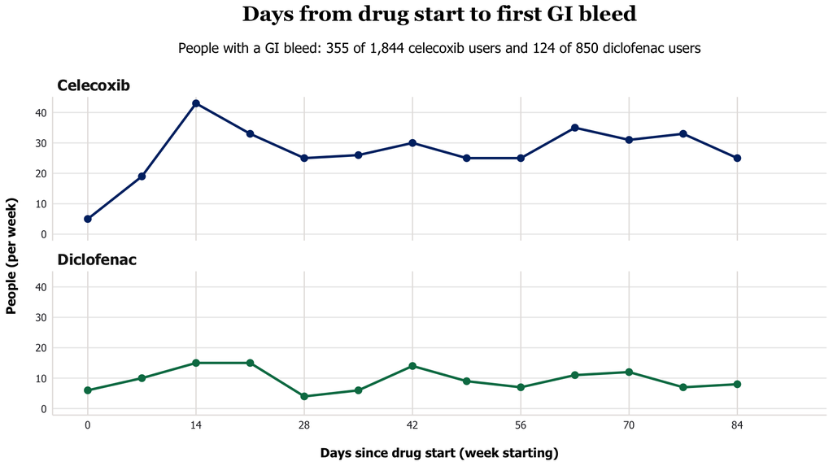

```r
# 3. Weekly counts, one panel per drug, common y axis
p_tte_facets <- ggplot(tte_weekly, aes(x = week_start, y = n, color = cohort)) +
  geom_line(linewidth = 1) +
  geom_point(size = 2.5) +
  facet_wrap(~cohort, ncol = 1) +
  scale_color_manual(values = drug_colors, guide = "none") +
  day_axis +
  expand_limits(y = 0) +
  labs(title = tte_title, subtitle = tte_subtitle,
       x = "Days since drug start (week starting)", y = "People (per week)") +
  theme_jhu() +
  theme(strip.text = element_text(size = 13, face = "bold", hjust = 0))
save_figure(p_tte_facets, "time-to-event-facets")
```

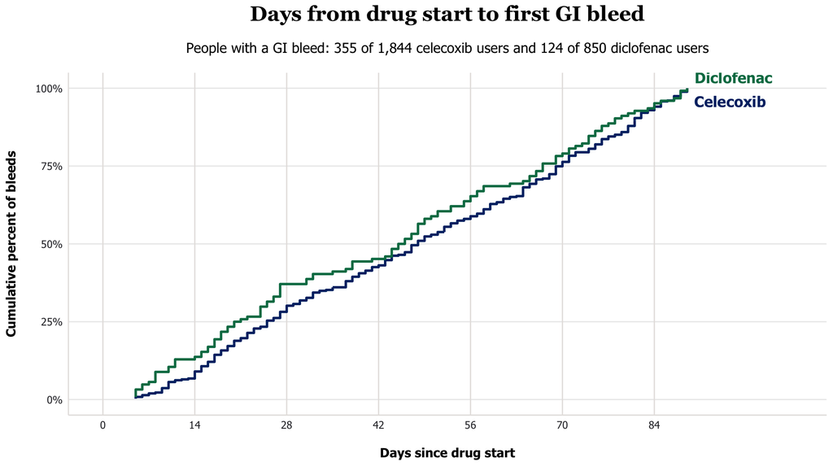

```r
# 4. Cumulative percent of each cohort's bleeds
p_cum <- ggplot(tte_cum, aes(x = daysToEvent, y = pct, color = cohort)) +
  geom_step(linewidth = 1) +
  geom_text(data = \(d) slice_max(d, daysToEvent, by = cohort, with_ties = FALSE),
            aes(label = cohort), hjust = -0.1, vjust = c(1.5, -0.5),
            fontface = "bold", size = 4.5) +
  scale_color_manual(values = drug_colors, guide = "none") +
  scale_x_continuous(breaks = seq(0, 91, by = 14), limits = c(0, 105)) +
  scale_y_continuous(labels = \(x) paste0(x, "%"), limits = c(0, 100)) +
  labs(title = tte_title, subtitle = tte_subtitle,
       x = "Days since drug start", y = "Cumulative percent of bleeds") +
  theme_jhu()
save_figure(p_cum, "time-to-event-cumulative")
```